# Gene Ontology enrichment

JF GOUT

# Gene ontology enrichement

We will use the results from the previous lab [https://jfgout.github.io/CMB8013-2026/HTML/RNAseq.html(https://jfgout.github.io/CMB8013-2026/HTML/RNAseq.html) to search for **functional categories** that are especially prone to gene expression change when yeast cells are grown in aerobic vs anaerobic conditions.

## Background information about Gene Ontology

Definition: The Gene Ontology (GO) is a comprehensive, structured, and controlled vocabulary system that defines and classifies the functions of genes and gene products across all species.

There are 3 domains:

- Biological Processes (BP)
- Molecular Functions (MF)
- Cellular Components (CC)

Inside each domain, there GO terms with different levels of specialization. For example, inside **Cellular Components** we can find **GO:0005634 nucleus**  
Definition: A membrane-bounded organelle of eukaryotic cells in which chromosomes are housed and replicated. In most cells, the nucleus contains all of the cell’s chromosomes except the organellar chromosomes, and is the site of RNA synthesis and processing. In some species, or in specialized cell types, RNA metabolism or DNA replication may be absent.

There is a total of 18,597,996 (as of March 31st, 2026) genes annotated as being part of this category (see: https://www.ebi.ac.uk/QuickGO/term/GO:0005634).

This GO Term is the **child** of several more generic GO terms:

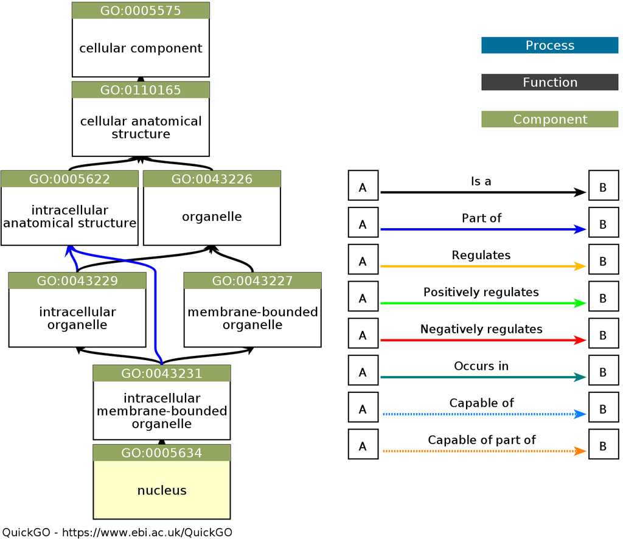

Ancestry map of GO:0005634

And GO:0005634 nucleus also has a number of child terms, which represent more specialized levels of information:

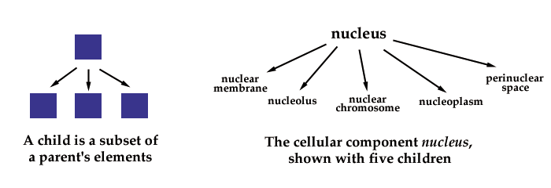

Childs map of GO:0005634 - From http://dictybase.org/db/html/help/GO.html

Many genes have been annotated as belonging to one or several GO categories (but the function of many genes remains a mystery…)

## Application to the yeast RNAseq data:

The goal here is to search for functional categories (represented by the Gene Ontologies) that are over (or under) represented among the differentially expressed genes. For example, one would expect that genes annotated as being part of **GO:0006113 fermentation** are more likely than a random gene to be differentially expressed upon switching from aerobic to anaerobic growth.  
We can use packages to search for significant functional categories. Here is an example:

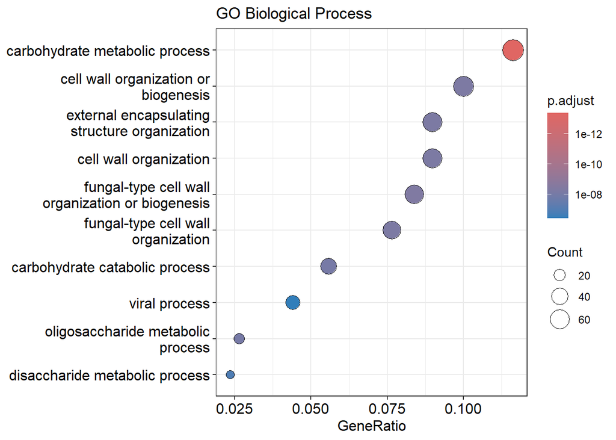

```r
library(clusterProfiler)
library(org.Sc.sgd.db)
library(apeglm)

# This code assumes that you already have the "res_df" object from the previous lab. This is a data.frame version fo the DESeq2 analysis result.

# First, we extract the list of significant genes. The program will use this to search for over-representation in the different ontologies
sig <- subset(res_df, padj < 0.05 & log2FoldChange > 1)
sig_genes <- rownames(sig)

# Looking at Biological Processes
ego_bp <- enrichGO(
  gene          = sig_genes,
  OrgDb         = org.Sc.sgd.db,
  keyType       = "ORF",
  ont           = "BP",
  pAdjustMethod = "BH",
  pvalueCutoff  = 0.05,
  qvalueCutoff  = 0.05,
  readable      = FALSE
)

# Looking at Molecular Function
ego_mf <- enrichGO(
  gene          = sig_genes,
  OrgDb         = org.Sc.sgd.db,
  keyType       = "ORF",
  ont           = "MF",
  pAdjustMethod = "BH",
  pvalueCutoff  = 0.05,
  qvalueCutoff  = 0.05,
  readable      = FALSE
)

# Looking at Cellular Component
ego_cc <- enrichGO(
  gene          = sig_genes,
  OrgDb         = org.Sc.sgd.db,
  keyType       = "ORF",
  ont           = "CC",
  pAdjustMethod = "BH",
  pvalueCutoff  = 0.05,
  qvalueCutoff  = 0.05,
  readable      = FALSE
)

dotplot(ego_bp, title = "GO Biological Process")
```

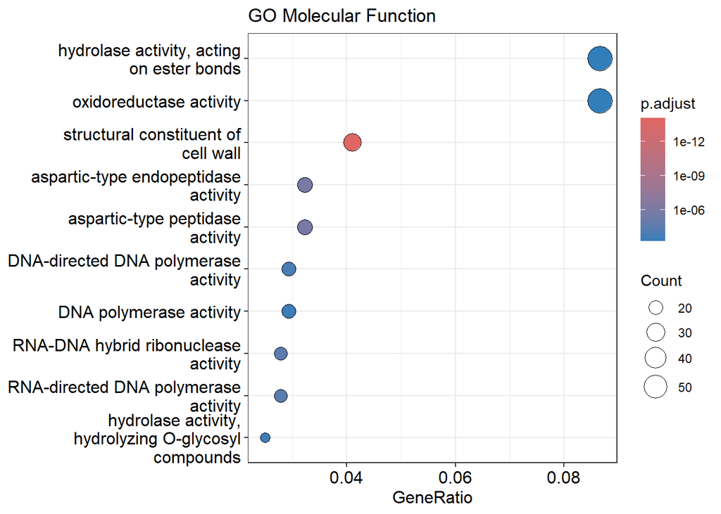

```r
dotplot(ego_mf, title = "GO Molecular Function")
```

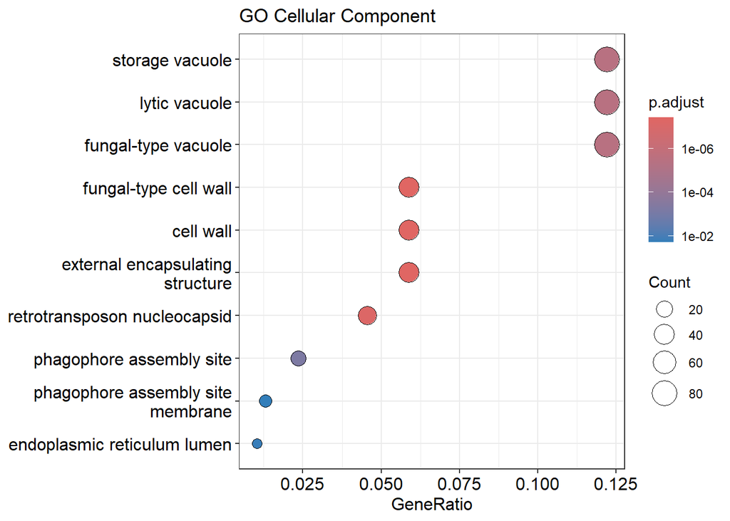

```r
dotplot(ego_cc, title = "GO Cellular Component")
```

## Understanding how these analyses work

You will now write your own function to test if a functional category is significantly associated with expression level changes. For this, you will need a way to fetch the list of genes annotated as being part of a given GO. For example, let’s look at **GO:0006113 fermentation**

To get the list of genes in this category:

```r
GO_ID <- "GO:0006113"

all_genes_in_term <- AnnotationDbi::select(
  org.Sc.sgd.db,
  keys     = GO_ID,
  keytype  = "GOALL",
  columns  = c("ORF", "COMMON", "GOALL", "ONTOLOGYALL")
)
head(all_genes_in_term)
```

```
##        GOALL EVIDENCEALL ONTOLOGYALL     ORF        SGD
## 1 GO:0006113         IEA          BP YDR050C S000002457
## 2 GO:0006113         IEA          BP YDR050C S000002457
## 3 GO:0006113         IEA          BP YCR012W S000000605
## 4 GO:0006113         IEA          BP YCR012W S000000605
## 5 GO:0006113         IGI          BP YGR177C S000003409
## 6 GO:0006113         IGI          BP YGR177C S000003409
##                            COMMON
## 1                            TPI1
## 2 triose-phosphate isomerase TPI1
## 3                            PGK1
## 4         phosphoglycerate kinase
## 5                            ATF2
## 6     alcohol O-acetyltransferase
```

```r
gene_go_list <- all_genes_in_term$ORF
```

From this, we will discuss in class the different steps required to perform the test. The key points are:

- How many genes belonging to a given GO term are expected to be differentially just by chance (-> null hypothesis)
- Is the difference from the null hypothesis significant?
- Statistical vs biological significance…

```r
# General structure of the program:

################################################################################
# testGO_enrichment; This function will test if a given Gene Ontology has a
# significant excess of differentially expressed genes.
#
# Input:
#   - siGenes: A vector with the IDs of all the differentially expressed genes.
#   - allGenes: A vector with the IDs of all the genes in yeast
#   - genesInGo: A vector with the IDs of all the genes that belong to the GO category being tested
#
testGO_enrichment <- function(sigGenes, allGenes, genesInGo){
  # We will perform a proportion test (prop.test) to compare the fraction of genes that
  # are differentially expressed between the tested functional category and the entire genome.

  # Return: the result from the prop.test function call.
}

# To call the function, we will need to perform a number of steps:

# 1. Let's load our DE analysis results:

setwd("/path_to-work_folder")

library(clusterProfiler)
library(org.Sc.sgd.db)
library(apeglm)

res <- readRDS("res_df_oxy-noAgent.bin")  # Loading previously saved DE results
res_df <- as.data.frame(res)      # Turning our res object into a data.frame
res_df$gene <- rownames(res_df)   # Adding a column with the gene ID

GO_ID <- "GO:0005975" # carbohydrate metabolic process

# Querying the online GO database to get the list of genes annotated in the selected GO category.
all_genes_in_term <- AnnotationDbi::select(
  org.Sc.sgd.db,
  keys     = GO_ID,
  keytype  = "GOALL",
  columns  = c("ORF", "COMMON", "GOALL", "ONTOLOGYALL")
)

# Having a quick look at the data:
head(all_genes_in_term)

all_genes_in_term <- # Find the code to get the list of gene IDs (we want the IDs that start with "Y")
  # There is one tricky part here: some genes can appear multiple times in the list.
  # Make sure to remove any redudancy.


MAX_PADJ <- 0.05
MIN_LFC <- 1

sigGenes <- # Find the code to get the list of genes that are significantly differentially expressed.
allGenes <- # Find the code that generates a vecotr with all the genes analyzed in this study.


testGO_enrichment(sigGenes = sigGenes, allGenes = allGenes, genesInGo = ? which variable do you use here ?)
```